[figure not shown]

# Python Interaction

Python provides powerful functionalities for generating and plotting figures. Rather than being comprehensive, we discuss in this notebook some concrete examples on how to generate images to visualize waveforms (audio signals), spectrograms (time–frequency representations), and other feature representations. Doing so, we introduce alternatives based on the Python library [Matplotlib](https://matplotlib.org) and the Python package [LibROSA](https://librosa.github.io/librosa/).

## Python Packages for Visualization

The library `matplotlib` is a widely used Python package for 2D-graphics, which allows a user to produce high-quality figures in a variety of formats as well as interactive environments across platforms. The [main website](https://matplotlib.org/) contains a detailed documentation and links to illustrative code examples. In particular, we recommend to have a look at the [gallery](https://matplotlib.org/gallery/index.html), which contains numerous examples of the many things you can do with `matplotlib`. In particular, we will use [`matplotlib.pyplot`](https://matplotlib.org/api/pyplot_api.html), which is a collection of command style functions that make matplotlib work like MATLAB. Following general convention, we use the following abbreviation:

`import matplotlib.pyplot as plt`

[LibROSA](https://librosa.github.io/librosa/) is a python package specifically desigend for music and audio analysis. While providing various building blocks necessary to create music information retrieval systems, LibROSA also contains a number of specialized visualization functions contained in [`librosa.display`](https://librosa.github.io/librosa/display.html). These functions, in turn, build on the library `matplotlib`. Using functions from LibROSA is often convenient, since they provide default settings and presets that have turned out to be meaningful in music processing scenarios. However, if not changed explicitly, these presets are applied automatically, which may lead to inconsistencies and unexpected effects. **Please make sure to understand the default settings and presets by looking into the source code!**

## Switching between Matplotlib's backends

Matplotlib has different backends for targeting different outputs. The default backend in a Jupyter notebook is the `inline` backend, which displays the output inline within the notebok. The command `%matplotlib inline` defines the used backend as `inline`.

**Links:**

- https://matplotlib.org/faq/usage_faq.html#what-is-a-backend
- https://matplotlib.org/api/index_backend_api.html
- https://ipython.readthedocs.io/en/stable/interactive/magics.html#magic-matplotlib
- https://ipython.readthedocs.io/en/stable/interactive/plotting.html

The following cells illustrate three different backends. You may have to restart the kernel to see their effects!

The `inline` backend displays the output inline within the notebok:

```
module://ipykernel.pylab.backend_inline
```

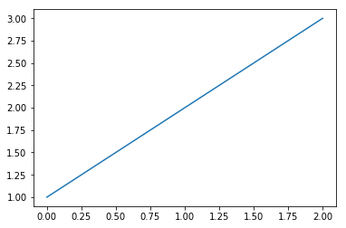

```python
import matplotlib
from matplotlib import pyplot as plt

%matplotlib inline


print(matplotlib.get_backend())

plt.plot([1, 2, 3])
```

The `qt` backend displays the output in a separate window created with Qt, a common GUI framework:

```
Qt5Agg
```

[figure not shown]

```python
import matplotlib
from matplotlib import pyplot as plt

%matplotlib qt

print(matplotlib.get_backend())

plt.plot([1, 2, 3])
```

The `notebook` backend displays the output inline in an interactive way, e.g. with zooming functionalities.

```python
import matplotlib
from matplotlib import pyplot as plt

%matplotlib notebook

print(matplotlib.get_backend())

plt.plot([1, 2, 3])
```

[output not shown]

**Acknowledgment:** This notebook was created by [Frank Zalkow](https://www.audiolabs-erlangen.de/fau/assistant/zalkow) and [Meinard Müller](https://www.audiolabs-erlangen.de/fau/professor/mueller).